# Análisis de las Mejores Ligas del Mundo (2019)

Yofran Perdomo

2022-03-07

## Transformación y Cleaning Data

El 80% del trabajo de un data scientist, en términos de tiempo, se dedica a la limpieza de los datos. En el presente proyecto, las variables value, wage, age, entre otras, tuvieron que ser editadas; Se eliminaron caracteres y se conviertieron a otro tipo de datos (caracteres a númericas). Además, se determinó la existencia de posibles NA, para evitar que determinadas operaciones estadísticas arrojen algún error en el código. La finalidad de este proceso es facilitar el manejo de los datos y el posterior análisis exploratorio que se empleará a los mismos.

```r
head(fifa19[, c("Wage", "Value", "Height", "Weight")])
```

```
##      Wage     Value Height Weight
## 1 â‚¬565K â‚¬110.5M    5'7 159lbs
## 2 â‚¬405K    â‚¬77M    6'2 183lbs
## 3 â‚¬290K â‚¬118.5M    5'9 150lbs
## 4 â‚¬260K    â‚¬72M    6'4 168lbs
## 5 â‚¬355K   â‚¬102M   5'11 154lbs
## 6 â‚¬340K    â‚¬93M    5'8 163lbs
```

## Gráficos y Análisis Exploratorio

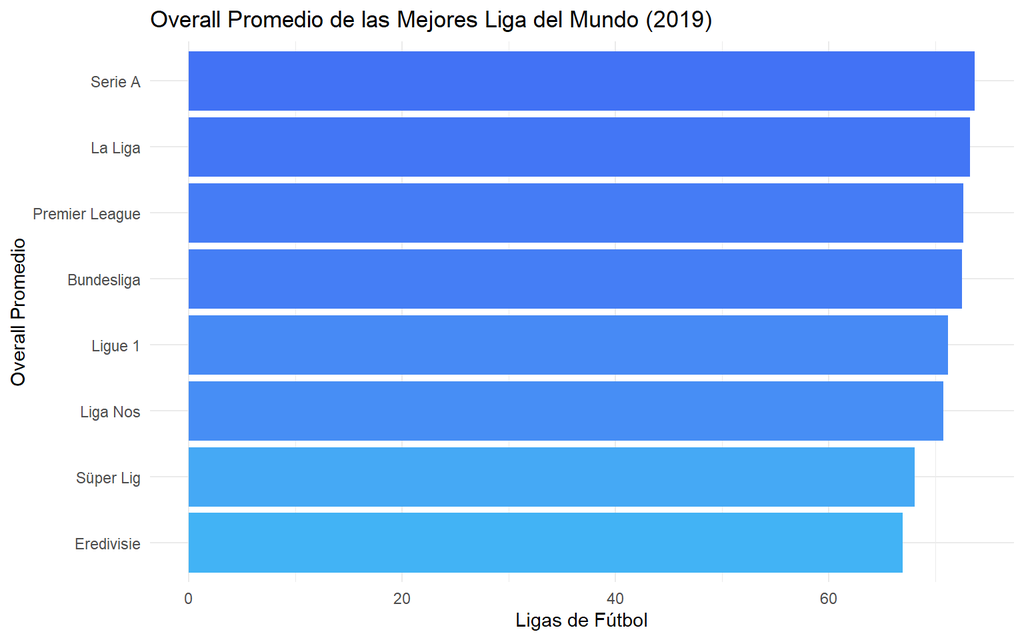

```r
# Nivel de overall segun la liga

datos_fifa %>%
  group_by(Ligas) %>%
  summarize(Promedio_overall = mean(Overall)) %>%
  ggplot(aes(reorder(Ligas, Promedio_overall), Promedio_overall, fill = Promedio_overall))+
  geom_col(show.legend = F)+
  coord_flip()+
  theme_minimal()+
  scale_fill_gradient(low = "#42b3f5", high = "#4272f5")+
  labs(x = "Overall Promedio", y = "Ligas de Fútbol",
       title = "Overall Promedio de las Mejores Liga del Mundo (2019)")
```

El overall es un indicador para medir la fuerza de juego de cualquier jugador. FIFA lo utiliza para determinar cuáles de sus jugadores, en promedio, tienen califican mejor para ciertas cualidades. Una vez agrupados los jugadores de acuerdo a su liga (país al que pertenece el club), es interesante notar que, contra todo pronóstico, la liga italiana tiene un mejor promedio para el overall. Esto no necesariamente implica que los mejores equipos están allí, dado que, como bien es sabido, el promedio es una medida que se ve afectada por los valores extremos, con lo cual debemos emplear otras medidas para determinar por qué razón la Serie A representa, en promedio, el mejor overall.

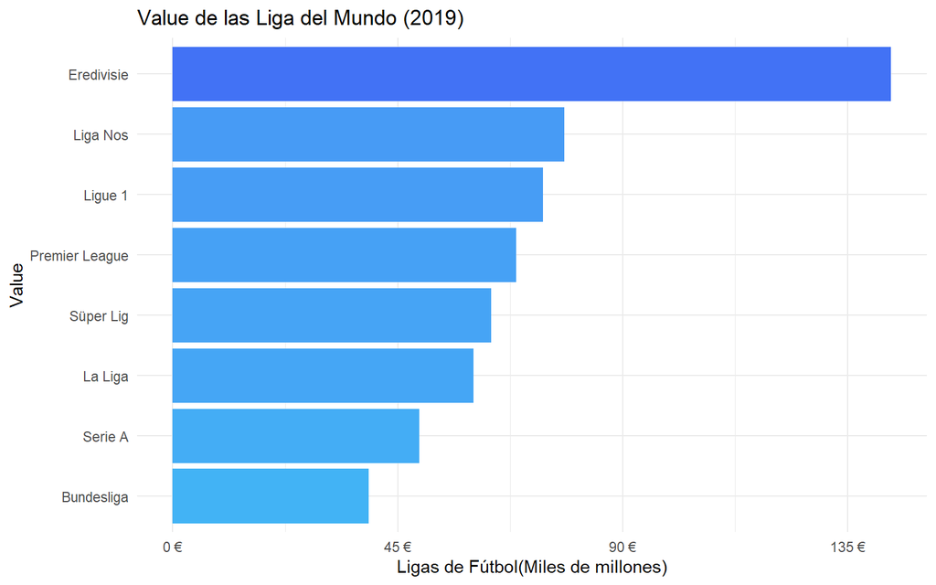

```r
# Valor de las ligas

datos_fifa %>%
  group_by(Ligas) %>%
  summarize(Promedio_Value = sum(Value)) %>%
  ggplot(aes(reorder(Ligas, Promedio_Value), Promedio_Value, fill = Promedio_Value))+
  geom_col(show.legend = F)+
  coord_flip()+
  theme_minimal()+
  scale_fill_gradient(low = "#42b3f5", high = "#4272f5")+
  labs(x = "Value", y = "Ligas de Fútbol(Miles de millones)",
       title = "Value de las Liga del Mundo (2019)")+
  scale_y_continuous(labels = c("0 €", "45 €", "90 €", "135 €"))
```

La liga más valiosa (en miles de millones) resultó ser la Eredivisie. Esto puede deberse, en parte, al ascenso de los clubes holandeses durante el año 2019; El Ajax de Amsterdan tuvo un incremento de valor gracias a su evolución futbolística y lo lejos que llegó en algunas competiciones europeas.

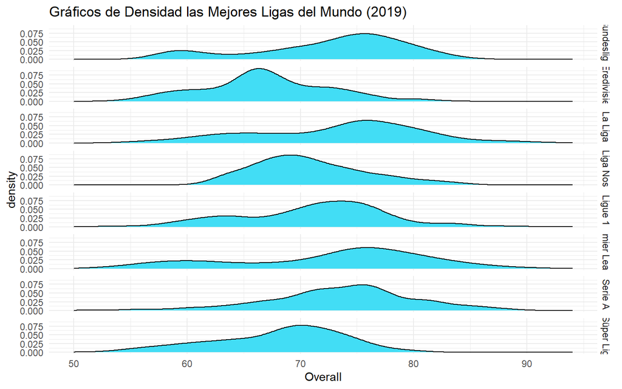

```r
# graficos de densidad
ggplot(datos_fifa, aes(Overall, fill = Ligas))+
  geom_density(show.legend = F)+
  theme_minimal()+
  facet_grid(Ligas~.)+
  scale_fill_manual(values = c(rep("#42ddf5", 8)))+
  labs(title = "Gráficos de Densidad las Mejores Ligas del Mundo (2019)")
```

Los gráficos de densidad representan un modelo útil a la hora de determinar aspectos relevantes como la bimodalidad o intentar explicar el comportamiento de una liga a través de una distribución conocida. El overall puede ayudarnos a describir el comportamiento de una liga, si la data es grupada a partir de las mismas. En este sentido, la Liga Nos (Portugal) representa el comportamiento más cercano a una distribución normal, con lo cual podemos apoyarnos en propiedades relevantes como la simetría y lo que esto significa, por ejemplo, la coincidencia/cercanía entre las medidas de tendencia central.

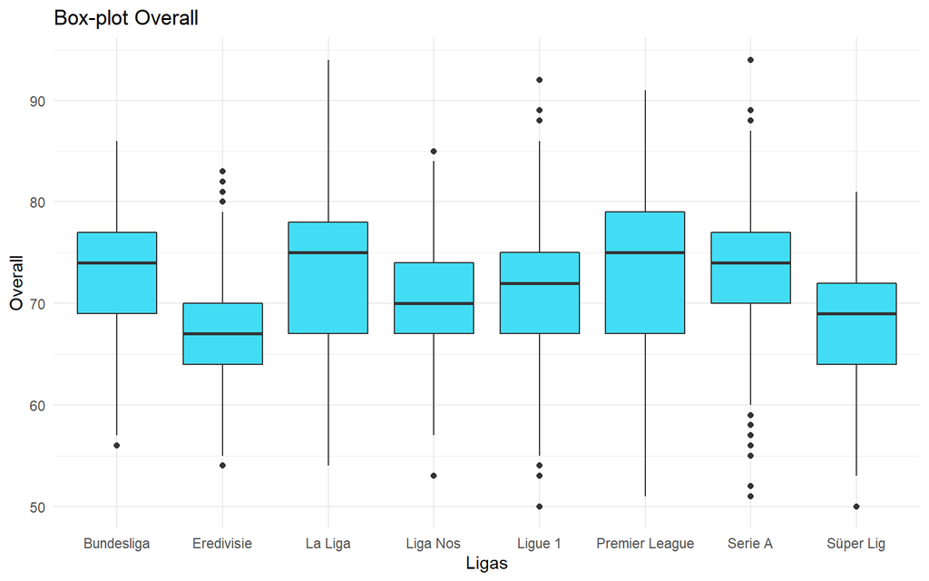

```r
# Boxplot
ggplot(datos_fifa, aes(Ligas, Overall, fill = Ligas))+
  geom_boxplot(show.legend = F)+
  theme_minimal()+
  scale_fill_manual(values = c("#42ddf5", "#42ddf5","#42ddf5","#42ddf5",
                               "#42ddf5","#42ddf5", "#42ddf5", "#42ddf5"))+
  labs(title = "Box-plot Overall")
```

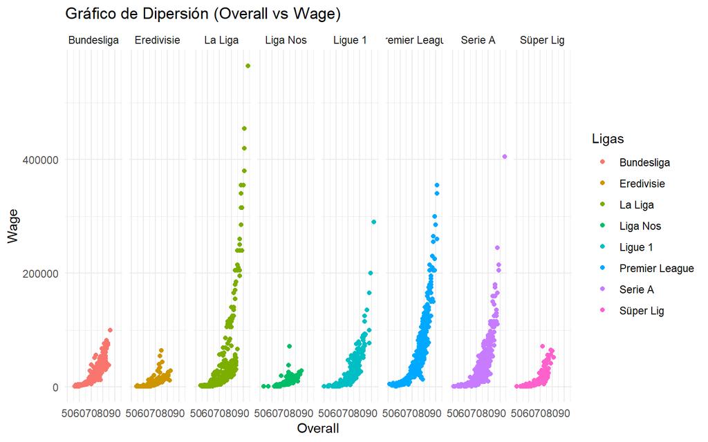

```r
# relacion del salario entre Overall
options(scipen=9999) # para trabajar sin notación científica
ggplot(datos_fifa, aes(Overall, Wage, color = Ligas))+
  geom_point()+
  theme_minimal()+
  facet_grid(~Ligas)+
  labs(title = "Gráfico de Dipersión (Overall vs Wage)")
```

```r
# Tabla que ayudara con la interpretación

datos_fifa %>%
  group_by(Ligas) %>%
  summarize(Correlación = cor(Overall, Wage))
```

```
## # A tibble: 8 x 2
##   Ligas          Correlación
##   <fct>                <dbl>
## 1 Bundesliga           0.836
## 2 Eredivisie           0.700
## 3 La Liga              0.598
## 4 Liga Nos             0.761
## 5 Ligue 1              0.737
## 6 Premier League       0.803
## 7 Serie A              0.753
## 8 Süper Lig            0.691
```

Los gráficos de correlación entre las variables Wage y Overall (overall vs salario) son útiles en un sentido muy claro; La afirmación “a medida que el overall es mayor, el salario será mayor” podrá tener (o no) sentido. Si examinamos detalladamente para cada una de las ligas, los resultados serán, naturalmente, diferentes. Los datos indican que, la Bundesliga es la liga en el cual están variables están mejor correlacionadas. Se observa además, que la correlación es alta en términos estadísticos, cerca del 84%. Si bien, para otrass ligas este correlación no es tan fuerte, es apreciable el efecto del overall en el salario.

```r
kbl(head(ligas))
```

| Ligas | Skill | Exp |
| --- | --- | --- |
| La Liga | Crossing | 55.88337 |
| Premier League | Crossing | 55.77932 |
| La Liga | Finishing | 52.06883 |
| Premier League | Finishing | 50.06944 |
| La Liga | HeadingAccuracy | 55.96558 |
| Premier League | HeadingAccuracy | 57.13117 |

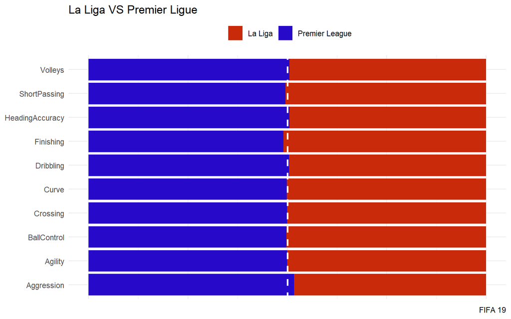

```r
options(repr.plot.width = 15, repr.plot.height = 8)

ggplot(ligas, aes(Skill, Exp, fill = Ligas))+
  geom_col(position = "fill")+
  coord_flip()+
  scale_fill_manual(values = c("#c92a0a", "#270ac9"))+
  theme_minimal()+
  geom_hline(yintercept = 0.5, color = "white", size = 1, linetype = 2)+
  theme(legend.position = "top", axis.text.x=element_blank())+
  labs(title = "La Liga VS Premier Ligue",
       caption = "FIFA 19",
       fill = NULL,x = NULL, y = NULL)
```

Podemos estar interesados en estadísticas particulares, para así contrastar entre, por ejemplo, dos ligas; En ese caso, podemos comparar La Liga con la Premier League y observar que, en promedio, el volleys (voleo) de los jugadores de ambas ligas es similar. En otros casos, se impone La Liga (véase short passing o finishing), así como también podemos observar que la Premier League se impone en agression

```r
head(jugadores)
```

```
##           Name           Skill Exp
## 1    Neymar Jr        Crossing  79
## 2 K. De Bruyne        Crossing  93
## 3    Neymar Jr       Finishing  87
## 4 K. De Bruyne       Finishing  82
## 5    Neymar Jr HeadingAccuracy  62
## 6 K. De Bruyne HeadingAccuracy  55
```

[figure not shown]

```r
# Gráfica para comparar los jugadores
ggplot(jugadores, aes(Skill, Exp, fill = Name))+
  geom_col(position = "fill")+
  coord_flip()+
  scale_fill_manual(values = c("#c92a0a", "#270ac9"))+
  theme_minimal()+
  geom_hline(yintercept = 0.5, color = "white", size = 1, linetype = 2)+
  theme(legend.position = "top", axis.text.x=element_blank())+
  labs(title = "Neymar Jr VS K. De Bruyne",
       caption = "FIFA 19",
       fill = NULL,x = NULL, y = NULL)
```

Este análisis comparativo puede ser más específico y llevarse a cabo no solo con ligas, sino también con jugadores; Un primer ejemplo es el De Bruyne VS Neymar. Dos jugadores de la élite deportiva futbolística hoy por hoy (y aún más en 2019). En ese sentido, De Bruyne (en rojo) se impone en muchos aspectos (visión de juego, fuerza, potencia de tiro, pases cortos, entre otros). Esta comparación resulta particularmente útil cuando se contrastan jugadores que pertenecen a la misma posición. Así, se puede encontrar quién es más efectivo.

## Comparación de los Finalistas de la Champions

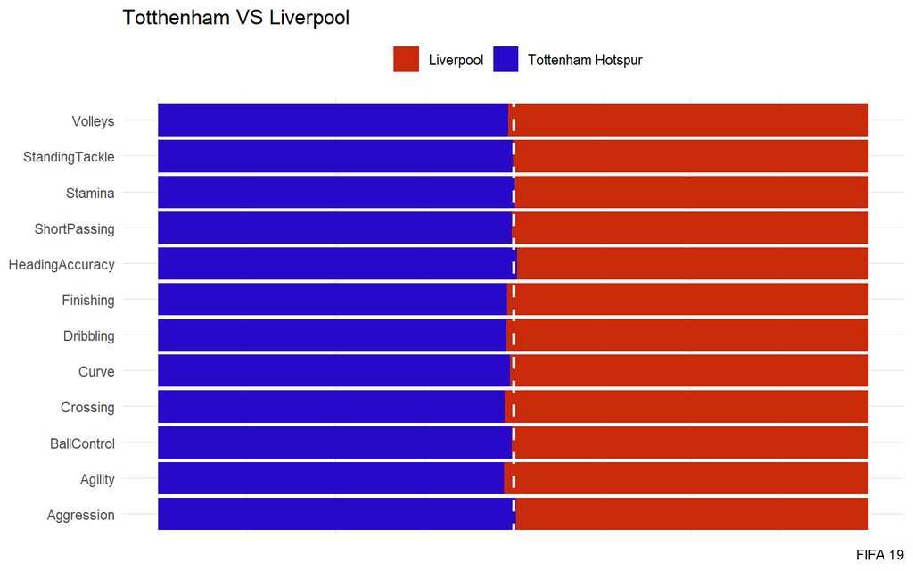

[figure not shown]

Resultado

```r
ggplot(vs, aes(Skill, Exp, fill = Club))+
  geom_col(position = "fill")+
  coord_flip()+
  scale_fill_manual(values = c("#c92a0a", "#270ac9"))+
  theme_minimal()+
  geom_hline(yintercept = 0.5, color = "white", size = 1, linetype = 2)+
  theme(legend.position = "top", axis.text.x=element_blank())+
  labs(title = "Totthenham VS Liverpool",
       caption = "FIFA 19",
       fill = NULL,x = NULL, y = NULL)
```

A pesar que la gráfica donde se comparan estos equipos, están muy parejas. Liverpool gana el partido, por lo que las variables solo nos permitiría formular hipótesis, más no describir la realidad.

# Medidas Resumenes de las Variables del Modelo

```r
datos_fifa$International.Reputation<- as.factor(datos_fifa$International.Reputation)
datos_fifa$Weight <- as.numeric(datos_fifa$Weight)


kbl(summary(datos_fifa[,c(2:6,8:38)]))
```

|  | Age | Overall | Potential | Value | Wage | Height | Weight | Crossing | Finishing | HeadingAccuracy | ShortPassing | Volleys | Dribbling | Curve | FKAccuracy | LongPassing | BallControl | Acceleration | SprintSpeed | Agility | Reactions | Balance | ShotPower | Jumping | Stamina | Strength | LongShots | Aggression | Interceptions | … |
| --- | --- | --- | --- | --- | --- | --- | --- | --- | --- | --- | --- | --- | --- | --- | --- | --- | --- | --- | --- | --- | --- | --- | --- | --- | --- | --- | --- | --- | --- | --- |
|  | Min. :16.00 | Min. :50.00 | Min. :58.00 | Min. : 1000000 | Min. : 1000 | Min. :1.550 | Min. :121.0 | Min. : 7.0 | Min. : 4.00 | Min. : 4.00 | Min. :11.00 | Min. : 5.00 | Min. : 5.00 | Min. : 6.00 | Min. : 7.00 | Min. :10.0 | Min. : 8.00 | Min. :13.00 | Min. :15.00 | Min. :18.00 | Min. :33.00 | Min. :20.00 | Min. : 2.00 | Min. :26.00 | Min. :13.00 | Min. :24.00 | Min. : 4.00 | Min. :11.00 | Min. : 3.0 | … |
|  | 1st Qu.:21.00 | 1st Qu.:67.00 | 1st Qu.:72.00 | 1st Qu.: 3900000 | 1st Qu.: 4000 | 1st Qu.:1.710 | 1st Qu.:157.0 | 1st Qu.:42.0 | 1st Qu.:32.00 | 1st Qu.:48.00 | 1st Qu.:60.00 | 1st Qu.:33.00 | 1st Qu.:55.00 | 1st Qu.:39.00 | 1st Qu.:33.00 | 1st Qu.:48.5 | 1st Qu.:60.00 | 1st Qu.:58.00 | 1st Qu.:58.00 | 1st Qu.:57.00 | 1st Qu.:62.00 | 1st Qu.:56.00 | 1st Qu.:52.00 | 1st Qu.:59.00 | 1st Qu.:56.00 | 1st Qu.:59.00 | 1st Qu.:36.00 | 1st Qu.:47.00 | 1st Qu.:28.0 | … |
|  | Median :24.00 | Median :72.00 | Median :77.00 | Median : 10000000 | Median : 13000 | Median :1.830 | Median :168.0 | Median :60.0 | Median :53.00 | Median :60.00 | Median :68.00 | Median :50.00 | Median :67.00 | Median :56.00 | Median :46.00 | Median :61.0 | Median :69.00 | Median :68.00 | Median :68.00 | Median :67.00 | Median :68.00 | Median :66.00 | Median :65.00 | Median :67.00 | Median :68.00 | Median :68.00 | Median :58.00 | Median :64.00 | Median :58.0 | … |
|  | Mean :24.77 | Mean :71.35 | Mean :76.57 | Mean :165622630 | Mean : 26178 | Mean :1.779 | Mean :167.4 | Mean :54.3 | Mean :49.04 | Mean :55.78 | Mean :63.82 | Mean :47.43 | Mean :60.69 | Mean :52.36 | Mean :46.59 | Mean :57.5 | Mean :63.86 | Mean :65.69 | Mean :65.79 | Mean :64.95 | Mean :67.43 | Mean :64.29 | Mean :60.54 | Mean :66.19 | Mean :64.12 | Mean :66.51 | Mean :51.82 | Mean :59.58 | Mean :50.8 | … |
|  | 3rd Qu.:28.00 | 3rd Qu.:76.00 | 3rd Qu.:80.00 | 3rd Qu.:250000000 | 3rd Qu.: 31000 | 3rd Qu.:1.890 | 3rd Qu.:176.0 | 3rd Qu.:69.0 | 3rd Qu.:66.00 | 3rd Qu.:69.00 | 3rd Qu.:74.00 | 3rd Qu.:63.00 | 3rd Qu.:74.00 | 3rd Qu.:68.00 | 3rd Qu.:62.00 | 3rd Qu.:69.0 | 3rd Qu.:75.00 | 3rd Qu.:76.00 | 3rd Qu.:76.00 | 3rd Qu.:75.00 | 3rd Qu.:74.00 | 3rd Qu.:75.00 | 3rd Qu.:74.00 | 3rd Qu.:74.00 | 3rd Qu.:75.00 | 3rd Qu.:75.00 | 3rd Qu.:68.00 | 3rd Qu.:73.00 | 3rd Qu.:71.0 | … |
|  | Max. :40.00 | Max. :94.00 | Max. :95.00 | Max. :975000000 | Max. :565000 | Max. :2.070 | Max. :229.0 | Max. :93.0 | Max. :95.00 | Max. :94.00 | Max. :93.00 | Max. :90.00 | Max. :97.00 | Max. :93.00 | Max. :94.00 | Max. :93.0 | Max. :96.00 | Max. :97.00 | Max. :96.00 | Max. :96.00 | Max. :96.00 | Max. :96.00 | Max. :95.00 | Max. :95.00 | Max. :96.00 | Max. :94.00 | Max. :94.00 | Max. :94.00 | Max. :92.0 | … |

## Correlaciones

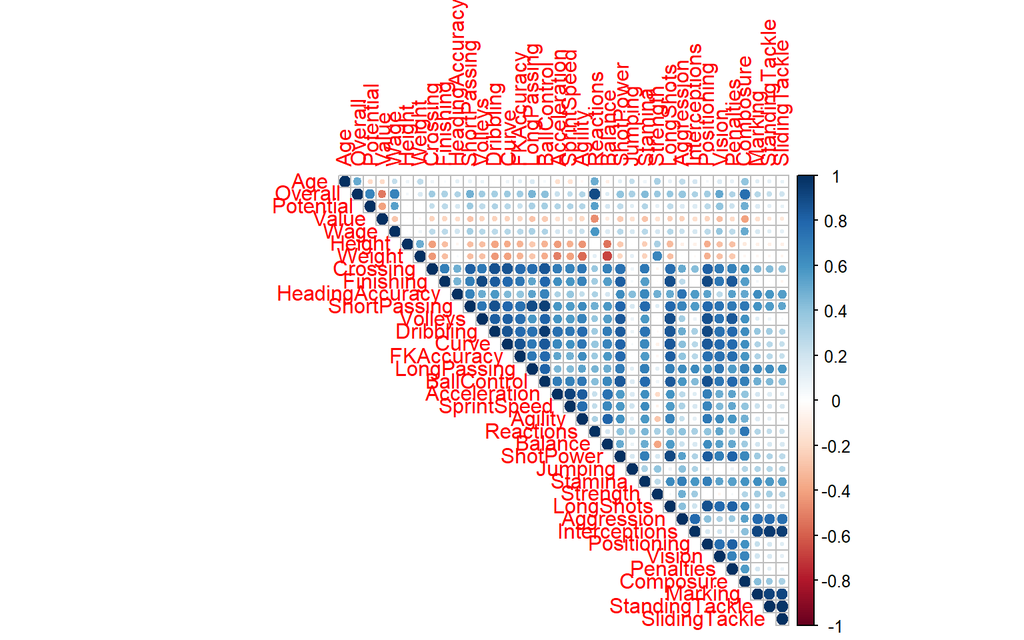

```r
corr <- datos_fifa[,c(2:6,8:38)]
correla <- cor(corr)

options(repr.plot.width = 50, repr.plot.height = 100)
corrplot(correla, type = "upper", method = "circle", number.cex = 9/ ncol(correla))
```

# Partición de Data

```r
# semilla
set.seed(143)

# Data de entrenamiento
particion <- sample(1:nrow(atacantes), size = 0.7*nrow(atacantes), replace = F)
fifa_train <- atacantes[particion,]
fifa_test <- atacantes[-particion,]
```

# Comportamiento del Salario

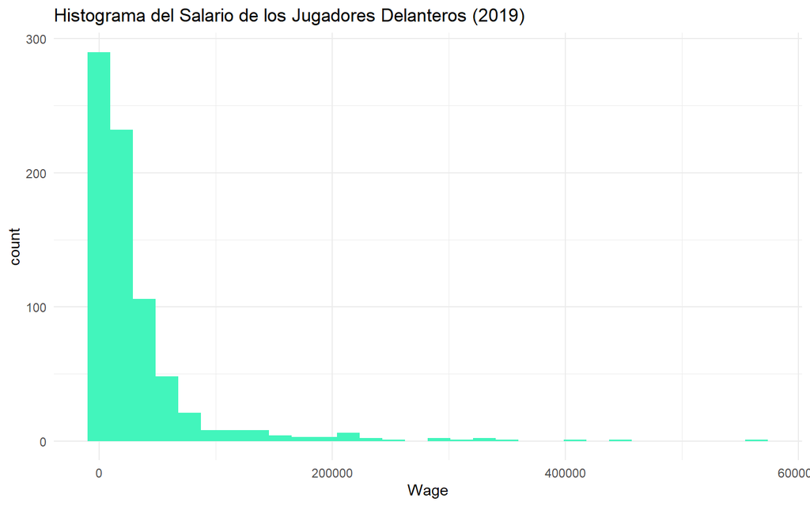

```r
ggplot(atacantes,
       aes(Wage))+
  geom_histogram(fill = "#42f5bc")+
  theme_minimal()+
  labs(title ="Histograma del Salario de los Jugadores Delanteros (2019)")
```

Se observa que el comportamiento tiene un sesgo hacia la derecha por lo tanto, para poder trabajar con el modelo, lo mejor seria que la variable tenga una distribución simétrica, por lo tanto se aplica Log.

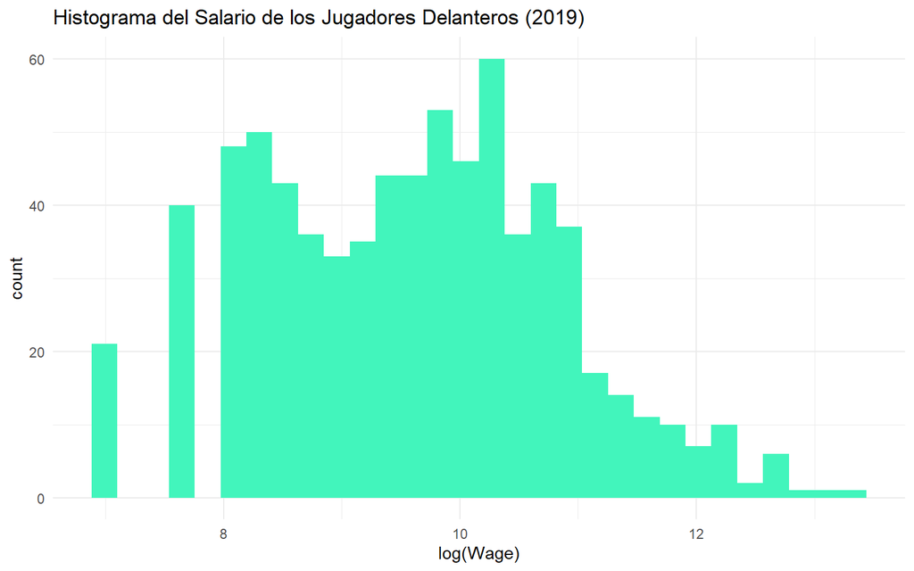

```r
ggplot(atacantes,
       aes(log(Wage)))+
  geom_histogram(fill = "#42f5bc")+
  theme_minimal()+
  labs(title ="Histograma del Salario de los Jugadores Delanteros (2019)", x = "log(Wage)")
```

# Construcción del Modelo

```r
modelo_step <- step(
    object = lm(log(Wage) ~.,
                fifa_train[,c(2:6,8:38)]),
   direction = "backward",
   scope = list(upper= ~., lower = ~1),
   trace = F
   )

modelo_step
```

```
##
## Call:
## lm(formula = log(Wage) ~ Overall + Potential + Value + Height +
##     Weight + Crossing + Curve + FKAccuracy + LongPassing + Balance +
##     Stamina + LongShots + Positioning + Marking, data = fifa_train[,
##     c(2:6, 8:38)])
##
## Coefficients:
##      (Intercept)           Overall         Potential             Value
## -4.1401785878042   0.0946755809563   0.0351859528376  -0.0000000002289
##           Height            Weight          Crossing             Curve
##  0.5579217484235   0.0060998756980   0.0108113807963  -0.0047941292050
##       FKAccuracy       LongPassing           Balance           Stamina
##  0.0050579133565  -0.0067907679939   0.0049226000352  -0.0071571426707
##        LongShots       Positioning           Marking
##  0.0102111966065   0.0192105534779   0.0036466464390
```

```r
summary(modelo_step)
```

```
##
## Call:
## lm(formula = log(Wage) ~ Overall + Potential + Value + Height +
##     Weight + Crossing + Curve + FKAccuracy + LongPassing + Balance +
##     Stamina + LongShots + Positioning + Marking, data = fifa_train[,
##     c(2:6, 8:38)])
##
## Residuals:
##      Min       1Q   Median       3Q      Max
## -1.31691 -0.41809 -0.04099  0.39706  1.51786
##
## Coefficients:
##                     Estimate       Std. Error t value        Pr(>|t|)
## (Intercept) -4.1401785878042  0.6564326292173  -6.307 0.0000000006179 ***
## Overall      0.0946755809563  0.0132093743610   7.167 0.0000000000027 ***
## Potential    0.0351859528376  0.0058383400893   6.027 0.0000000032142 ***
## Value       -0.0000000002289  0.0000000001044  -2.194         0.02871 *
## Height       0.5579217484235  0.2162058905910   2.581         0.01014 *
## Weight       0.0060998756980  0.0022981436823   2.654         0.00820 **
## Crossing     0.0108113807963  0.0035134498369   3.077         0.00220 **
## Curve       -0.0047941292050  0.0033016493965  -1.452         0.14711
## FKAccuracy   0.0050579133565  0.0028491121344   1.775         0.07645 .
## LongPassing -0.0067907679939  0.0036495245026  -1.861         0.06336 .
## Balance      0.0049226000352  0.0031592442970   1.558         0.11982
## Stamina     -0.0071571426707  0.0030424173320  -2.352         0.01903 *
## LongShots    0.0102111966065  0.0043766978035   2.333         0.02003 *
## Positioning  0.0192105534779  0.0069638126739   2.759         0.00601 **
## Marking      0.0036466464390  0.0022817213552   1.598         0.11062
## ---
## Signif. codes:  0 '***' 0.001 '**' 0.01 '*' 0.05 '.' 0.1 ' ' 1
##
## Residual standard error: 0.5672 on 509 degrees of freedom
## Multiple R-squared:  0.8079, Adjusted R-squared:  0.8026
## F-statistic: 152.9 on 14 and 509 DF,  p-value: < 0.00000000000000022
```

El modelo es bueno, debido a que R-cuadrado es bastante alto. La variabilidad del modelo es explicado en un 81%, el p-valor indica que el modelo es significativo. Es un buen modelo para formar la variable Wage.

# Residuos

```r
shapiro.test(residuals(modelo_step))
```

```
##
##  Shapiro-Wilk normality test
##
## data:  residuals(modelo_step)
## W = 0.98937, p-value = 0.0007572
```

Los residuos no se ajustan a una distribución normal, por lo que el modelo puede contener algunas deficiencias.

# RMSE

```r
fifa_train %>%
  transmute(Name = fifa_train$Name,
            Wage = Wage,
            residuals = residuals(modelo_step)) %>%
  summarize(rmse = mean(residuals**2))
```

```
##        rmse
## 1 0.3125424
```

El error cuádratico medio indica un buen ajuste. Por lo tanto, se tomará en cuenta el salario de los jugadores real y el del modelo.

# Salarios Top (Modelo vs Real)

```r
top_wage <- datos_fifa %>%
  transmute(Name = datos_fifa$Name,
            Wage = Wage,
            valor_p = exp(predict(modelo_step, datos_fifa))) %>%
  top_n(Wage, 10)
head(top_wage, 10)
```

```
##                 Name   Wage  valor_p
## 1           L. Messi 565000 523052.2
## 2  Cristiano Ronaldo 405000 536473.9
## 3          Neymar Jr 290000 283860.9
## 4             De Gea 260000  21772.4
## 5       K. De Bruyne 355000 263551.4
## 6          E. Hazard 340000 250787.7
## 7         L. ModriÄ‡ 420000 210803.5
## 8         L. SuÃ¡rez 455000 390492.0
## 9       Sergio Ramos 380000 131495.6
## 10          T. Kroos 355000 252809.6
```

Según el modelo, Cristiano Ronaldo gana por encima de Messi. También se observa que existen jugadores que ganan en la realidad el doble de lo que indica el modelo, o valores muy por debajo o muy por encima.